# Effect of Walking Fitness on Brain Health

# Partial-effect curve

We plot a partial-effect curve showing the calibrated BAG across the range of two-minute walk distance while holding other covariates constant.

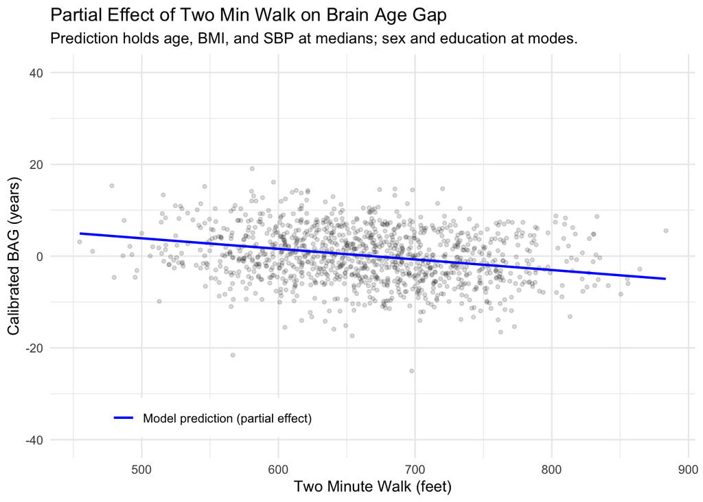

# Effect Summary

We summarize the estimated association as change in calibrated BAG per 100 feet walked (with 95% CI), and implied change in calibrated BAG moving from the 25th to 75th percentile of walking distance.

Association between 2-minute walk distance and calibrated brain age gap (BAG)

| Metric | Estimate | 95% CI (lower) | 95% CI (upper) |
| --- | --- | --- | --- |
| Effect per 100 feet (years BAG / 100 ft) | -2.30 | -2.86 | -1.74 |
| Two-minute walk (25th percentile, feet) | 612.43 | NA | NA |
| Two-minute walk (75th percentile, feet) | 713.19 | NA | NA |
| Δ Walk (75th - 25th, feet) | 100.76 | NA | NA |
| Implied Δ BAG from 25th→75th (years) | -2.32 | NA | NA |

# Appendix

## XGBoost hyperparameter optimization (optional)

This section reproduces the model-based hyperparameter search used to select XGBoost parameters. It is turned off by default because it can take substantial time to run.

```r
# Changing VIEW_DEMO_OF_HYPERPARAMATER_OPTIMIZATION to TRUE will run demo of hyperparamater optimization for XGBOOST
# Best performing hyperparameters are already in use in the code above

# ------------------------------------------------------------ #
# WARNING: This can take over 30 minutes on a standard laptop  #
# ------------------------------------------------------------ #
VIEW_DEMO_OF_HYPERPARAMATER_OPTIMIZATION = FALSE
if (VIEW_DEMO_OF_HYPERPARAMATER_OPTIMIZATION) {
  task = as_task_regr(MRI_df[,-1], target = "age")

  learner = lrn("regr.xgboost",
                booster = "gbtree",
                objective = "reg:squarederror",
                eval_metric = "rmse",
                tree_method = "hist",
                nrounds = 20000,
                early_stopping_rounds = 80,
                validate = "test",
                verbose = 0)

  search_space = ps(
    eta = p_dbl(0.008, 0.03),
    max_depth = p_int(2L, 4L),
    min_child_weight = p_dbl(50, 140),
    subsample = p_dbl(0.55, 0.85),
    colsample_bytree = p_dbl(0.06, 0.18),
    lambda = p_dbl(0, 20),
    alpha = p_dbl(1, 4),
    gamma = p_dbl(2, 9),
    colsample_bynode = p_dbl(0.08, 0.25))

  resampling = rsmp("cv", folds = 5)
  resampling$instantiate(task)
  measure = msr("regr.rmse")
  tuner = tnr("mbo")
  terminator = trm("evals", n_evals = 60)

  instance = TuningInstanceBatchSingleCrit$new(
    task = task,
    learner = learner,
    resampling = resampling,
    measure = measure,
    search_space = search_space,
    terminator = terminator
  )

  print(tuner$optimize(instance))
  print(instance$result)
}
```